# NEON_group_project

# Final work with merged datasets (4-27-25)

## Modeling merged C+N

```r
D02.D03.D08.D19.fulljoin.CN.test <- read.csv("D02.D03.D08.D19.fulljoin.CN.test.csv")
```

### Aboveground

```r
AGBmodel <- lme(InorganicN.kgHectare ~ AGB.C.Mg.ha + domainID + AGB.C.Mg.ha*domainID,
               random = ~1 | siteID/plotID,
               correlation = corAR1(),
               data = D02.D03.D08.D19.fulljoin.CN.test,
              na.action=na.exclude)
summary(AGBmodel)
```

```
## Linear mixed-effects model fit by REML
##   Data: D02.D03.D08.D19.fulljoin.CN.test
##        AIC      BIC    logLik
##   5562.084 5617.903 -2769.042
##
## Random effects:
##  Formula: ~1 | siteID
##         (Intercept)
## StdDev:    4.063752
##
##  Formula: ~1 | plotID %in% siteID
##         (Intercept) Residual
## StdDev:    1.975116 8.050101
##
## Correlation Structure: AR(1)
##  Formula: ~1 | siteID/plotID
##  Parameter estimate(s):
##          Phi
## -0.001973296
## Fixed effects:  InorganicN.kgHectare ~ AGB.C.Mg.ha + domainID + AGB.C.Mg.ha *      domainID
##                             Value Std.Error  DF   t-value p-value
## (Intercept)             12.895431  2.675218 718  4.820329  0.0000
## AGB.C.Mg.ha             -0.015860  0.015887  49 -0.998314  0.3230
## domainIDD03             -7.581361  3.889397   7 -1.949238  0.0923
## domainIDD08             -1.929497  3.786354   7 -0.509592  0.6260
## domainIDD19             -6.811992  4.434006   7 -1.536306  0.1683
## AGB.C.Mg.ha:domainIDD03 -0.014773  0.046133  49 -0.320233  0.7502
## AGB.C.Mg.ha:domainIDD08  0.006857  0.020430  49  0.335643  0.7386
## AGB.C.Mg.ha:domainIDD19  0.235566  0.067212  49  3.504820  0.0010
##  Correlation:
##                         (Intr) AGB.C.Mg. dIDD03 dIDD08 dIDD19 AGB.C.M.:IDD03
## AGB.C.Mg.ha             -0.295
## domainIDD03             -0.688  0.203
## domainIDD08             -0.707  0.208     0.486
## domainIDD19             -0.603  0.178     0.415  0.426
## AGB.C.Mg.ha:domainIDD03  0.101 -0.344    -0.383 -0.072 -0.061
## AGB.C.Mg.ha:domainIDD08  0.229 -0.778    -0.158 -0.356 -0.138  0.268
## AGB.C.Mg.ha:domainIDD19  0.070 -0.236    -0.048 -0.049 -0.289  0.081
##                         AGB.C.M.:IDD08
## AGB.C.Mg.ha
## domainIDD03
## domainIDD08
## domainIDD19
## AGB.C.Mg.ha:domainIDD03
## AGB.C.Mg.ha:domainIDD08
## AGB.C.Mg.ha:domainIDD19  0.184
##
## Standardized Within-Group Residuals:
##        Min         Q1        Med         Q3        Max
## -1.7002527 -0.4112736 -0.1613872  0.1379739 13.2544493
##
## Number of Observations: 782
## Number of Groups:
##             siteID plotID %in% siteID
##                 11                 64
```

### Results from Aboveground

#No C stock effect on Inorg N

#No effect of domain only on Inorg N

#One Significant interaction between domain + aboveground C on inorgN at D19 (Value=0.235566, SE=0.067212, DF= 49, t=3.504820, p = 0.0010).

### Roots

```r
rootsmodel <- lme(InorganicN.kgHectare ~ mean.root.MgC.ha + domainID + mean.root.MgC.ha*domainID,
               random = ~1 | siteID/plotID,
               correlation = corAR1(),
               data = D02.D03.D08.D19.fulljoin.CN.test,
              na.action=na.exclude)
summary(rootsmodel)
```

```
## Linear mixed-effects model fit by REML
##   Data: D02.D03.D08.D19.fulljoin.CN.test
##        AIC      BIC    logLik
##   3918.914 3970.052 -1947.457
##
## Random effects:
##  Formula: ~1 | siteID
##         (Intercept)
## StdDev:    5.318038
##
##  Formula: ~1 | plotID %in% siteID
##         (Intercept) Residual
## StdDev:  0.00125001 9.490899
##
## Correlation Structure: AR(1)
##  Formula: ~1 | siteID/plotID
##  Parameter estimate(s):
##       Phi
## 0.1268289
## Fixed effects:  InorganicN.kgHectare ~ mean.root.MgC.ha + domainID + mean.root.MgC.ha *      domainID
##                                   Value Std.Error  DF   t-value p-value
## (Intercept)                   22.335021  3.896976 488  5.731372  0.0000
## mean.root.MgC.ha              -2.382435  0.633862  29 -3.758600  0.0008
## domainIDD03                  -19.756165  5.133434   7 -3.848528  0.0063
## domainIDD08                  -12.391537  6.302686   7 -1.966072  0.0900
## domainIDD19                  -13.507408  9.457196   7 -1.428268  0.1963
## mean.root.MgC.ha:domainIDD03   2.541756  0.703383  29  3.613617  0.0011
## mean.root.MgC.ha:domainIDD08   2.859296  1.265745  29  2.258983  0.0316
## mean.root.MgC.ha:domainIDD19   2.588315  1.023142  29  2.529770  0.0171
##  Correlation:
##                              (Intr) mn..MC. dIDD03 dIDD08 dIDD19 m..MC.:IDD03
## mean.root.MgC.ha             -0.568
## domainIDD03                  -0.759  0.431
## domainIDD08                  -0.618  0.351   0.469
## domainIDD19                  -0.412  0.234   0.313  0.255
## mean.root.MgC.ha:domainIDD03  0.512 -0.901  -0.468 -0.316 -0.211
## mean.root.MgC.ha:domainIDD08  0.284 -0.501  -0.216 -0.697 -0.117  0.451
## mean.root.MgC.ha:domainIDD19  0.352 -0.620  -0.267 -0.217 -0.779  0.558
##                              m..MC.:IDD08
## mean.root.MgC.ha
## domainIDD03
## domainIDD08
## domainIDD19
## mean.root.MgC.ha:domainIDD03
## mean.root.MgC.ha:domainIDD08
## mean.root.MgC.ha:domainIDD19  0.310
##
## Standardized Within-Group Residuals:
##        Min         Q1        Med         Q3        Max
## -1.9037786 -0.3588299 -0.1141559  0.1403698 13.0271137
##
## Number of Observations: 532
## Number of Groups:
##             siteID plotID %in% siteID
##                 11                 44
```

### Results from roots

#Domain 3 has significantly lower InorgN to Root C than Domain 2 (value = -19.756165, SE=5.133434, DF=7, t = -3.848528, p = 0.0063).

#I got lazy - all interactions signif. (p<0.05)

### Soil

```r
soilmodel <- lme(InorganicN.kgHectare ~ soil.C.Mg.ha + domainID + soil.C.Mg.ha*domainID,
               random = ~1 | siteID/plotID,
               correlation = corAR1(),
               data = D02.D03.D08.D19.fulljoin.CN.test,
              na.action=na.exclude)
summary(soilmodel)
```

```
## Linear mixed-effects model fit by REML
##   Data: D02.D03.D08.D19.fulljoin.CN.test
##        AIC      BIC    logLik
##   4756.438 4808.959 -2366.219
##
## Random effects:
##  Formula: ~1 | siteID
##         (Intercept)
## StdDev:    4.678967
##
##  Formula: ~1 | plotID %in% siteID
##         (Intercept) Residual
## StdDev:    10.55575 11.77549
##
## Correlation Structure: AR(1)
##  Formula: ~1 | siteID/plotID
##  Parameter estimate(s):
##        Phi
## 0.01626534
## Fixed effects:  InorganicN.kgHectare ~ soil.C.Mg.ha + domainID + soil.C.Mg.ha *      domainID
##                               Value Std.Error  DF    t-value p-value
## (Intercept)               14.596490  7.039330 547  2.0735624  0.0386
## soil.C.Mg.ha              -0.020223  0.055207  35 -0.3663011  0.7163
## domainIDD03              -21.407303  9.094599   6 -2.3538479  0.0568
## domainIDD08              -13.477883 13.503885   6 -0.9980745  0.3568
## domainIDD19              -14.762957 30.762093   6 -0.4799074  0.6483
## soil.C.Mg.ha:domainIDD03   0.241766  0.082945  35  2.9147926  0.0062
## soil.C.Mg.ha:domainIDD08   0.109541  0.114587  35  0.9559633  0.3456
## soil.C.Mg.ha:domainIDD19   0.150241  0.254736  35  0.5897919  0.5591
##  Correlation:
##                          (Intr) sl.C.M. dIDD03 dIDD08 dIDD19 s.C.M.:IDD03
## soil.C.Mg.ha             -0.807
## domainIDD03              -0.774  0.625
## domainIDD08              -0.521  0.421   0.403
## domainIDD19              -0.229  0.185   0.177  0.119
## soil.C.Mg.ha:domainIDD03  0.537 -0.666  -0.773 -0.280 -0.123
## soil.C.Mg.ha:domainIDD08  0.389 -0.482  -0.301 -0.905 -0.089  0.321
## soil.C.Mg.ha:domainIDD19  0.175 -0.217  -0.135 -0.091 -0.944  0.144
##                          s.C.M.:IDD08
## soil.C.Mg.ha
## domainIDD03
## domainIDD08
## domainIDD19
## soil.C.Mg.ha:domainIDD03
## soil.C.Mg.ha:domainIDD08
## soil.C.Mg.ha:domainIDD19  0.104
##
## Standardized Within-Group Residuals:
##         Min          Q1         Med          Q3         Max
## -5.16707749 -0.27330088 -0.07570942  0.07304860 10.12670901
##
## Number of Observations: 596
## Number of Groups:
##             siteID plotID %in% siteID
##                 10                 49
```

### Results from soil

#No C stock effect on Inorg N

#No effect of domain only on Inorg N

#One Significant interaction between domain + soil C on inorgN at D03 (value = 0.241766, SE=0.082945, DF=35, t=2.9147926, p=0.0062).

### Visualization

#New dataframes w/ predict

```r
AGBmodeldf <- D02.D03.D08.D19.fulljoin.CN.test %>%
  filter(!is.na(AGB.C.Mg.ha), !is.na(InorganicN.kgHectare))
soilmodeldf <- D02.D03.D08.D19.fulljoin.CN.test %>%
  filter(!is.na(soil.C.Mg.ha), !is.na(InorganicN.kgHectare))
rootsmodeldf <- D02.D03.D08.D19.fulljoin.CN.test %>%
  filter(!is.na(mean.root.MgC.ha), !is.na(InorganicN.kgHectare))
AGBmodeldf$pred <- predict(AGBmodel, newdata = AGBmodeldf, level=1)
soilmodeldf$pred <- predict(soilmodel, newdata = soilmodeldf, level=1)
rootsmodeldf$pred <- predict(rootsmodel, newdata = rootsmodeldf, level=1)
```

#Aboveground plot

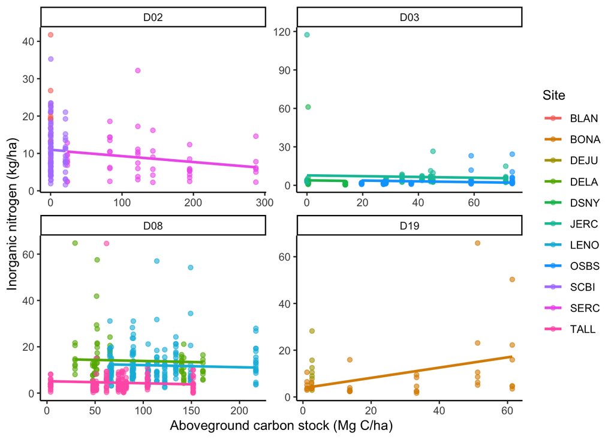

```r
AGBplot <- ggplot(AGBmodeldf, aes(x = AGB.C.Mg.ha, y = InorganicN.kgHectare, color = siteID)) +
  geom_point(alpha = 0.6) +
       geom_line(data = AGBmodeldf, aes(x = AGB.C.Mg.ha, y = pred, group = siteID), linewidth = 1) +
  facet_wrap(~ domainID, nrow=2, scales = "free") +
  theme_minimal() +
  labs(
    x = "Aboveground carbon stock (Mg C/ha)",
    y = "Inorganic nitrogen (kg/ha)",
    color = "Site"
  ) +
  theme(strip.text = element_text(size = 12),
        legend.position = "bottom")+
    theme_classic()

AGBplot
```

#Soil plot

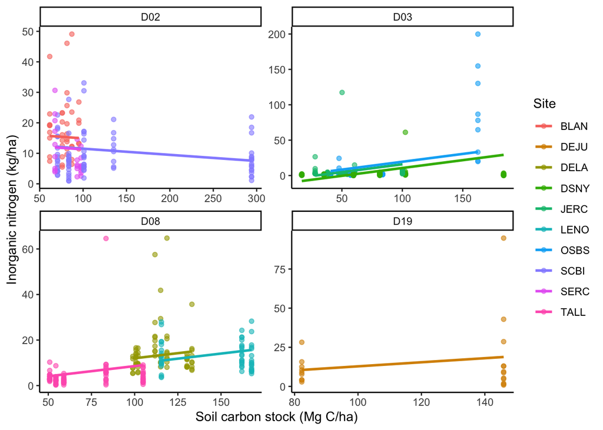

```r
soilplot <- ggplot(soilmodeldf, aes(x = soil.C.Mg.ha, y = InorganicN.kgHectare, color = siteID)) +
  geom_point(alpha = 0.6) +
       geom_line(data = soilmodeldf, aes(x = soil.C.Mg.ha, y = pred, group = siteID), linewidth = 1) +
  facet_wrap(~ domainID, nrow=2, scales = "free") +
  theme_minimal() +
  labs(
    x = "Soil carbon stock (Mg C/ha)",
    y = "Inorganic nitrogen (kg/ha)",
    color = "Site"
  ) +
  theme(strip.text = element_text(size = 12),
        legend.position = "bottom")+
    theme_classic()

soilplot
```

#Roots plot

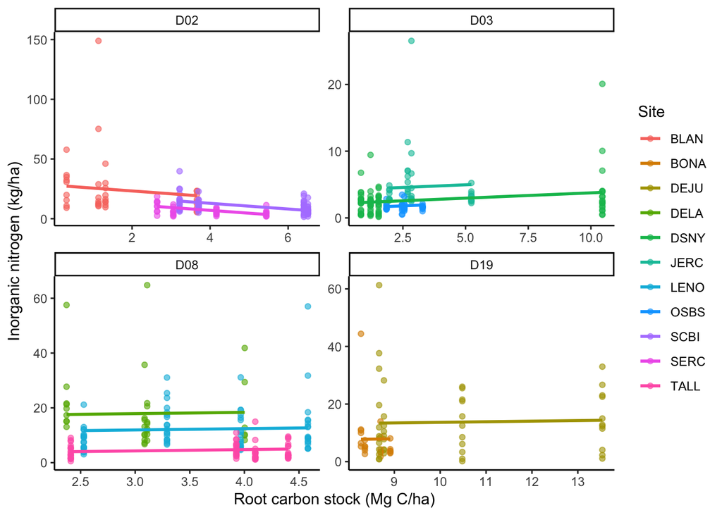

```r
rootsplot <- ggplot(rootsmodeldf, aes(x = mean.root.MgC.ha, y = InorganicN.kgHectare, color = siteID)) +
  geom_point(alpha = 0.6) +
       geom_line(data = rootsmodeldf, aes(x = mean.root.MgC.ha, y = pred, group = siteID), linewidth = 1) +
  facet_wrap(~ domainID, nrow=2, scales = "free") +
  theme_minimal() +
  labs(
    x = "Root carbon stock (Mg C/ha)",
    y = "Inorganic nitrogen (kg/ha)",
    color = "Site"
  ) +
  theme(strip.text = element_text(size = 12),
        legend.position = "bottom")+
    theme_classic()

rootsplot
```